# SNAP - StaMPS workflow for PS processing

Creating displacement maps using Sentinel-1 data

Thorsten Höser, [Researchgate](https://www.researchgate.net/profile/Thorsten_Hoeser), [GitHub](https://github.com/thho)

2019-04-24

# Comment

This document is part of the appendix of the master thesis: Analysing the Capabilities and Limitations of InSAR using Sentinel-1 Data for Landslide Detection and Monitoring.  
DOI: 10.13140/RG.2.2.35085.59362

The code within this script can be used for preprocessing S1 SLC data for StaMPS. Meanwihle, there is the snap2stamps package which is better maintained and more up to date, therefore I recommend using it. Anyway, for a btter understanding what is happening under the hood during preprocessing, this documentation and the master thesis referred to earlier is still a good start!

The content of this document has no claim to be correct and comes with absolutely no warranty.

Parts of this document are based on discussions and presented workflows from [MAINSAR](https://groups.google.com/forum/#!topic/mainsar/38KZ2-6nbrI) and the [step forum](http://forum.step.esa.int/t/workflow-between-snap-and-stamps/3211/9). Thanks to all members and developers contributing ideas and solving problems.

# 1 About this document

The guidance given in this summary are technically. It is absolutely necessary to know the basics of the theoretical background on radar remote sensing and InSAR. Here is some recommended literature.

**Introductions to InSAR and DInSAR:**  
Franceschetti and Lanari (1999), Rosen et al. (2000), Lauknes (2004), Ferretti et al. (2007) and Simons and Rosen (2007)

**Persistent Scatterer:**  
Ferretti et al. (2000), Ferretti et al. (2001)

**Small Baseline Subset:**  
Berardino et al. (2002)

**StaMPS/MTI literature:** Hooper et al. (2004), Hooper (2006), Hooper et al. (2007), Hooper (2008), Hooper (2010), Hooper et al. (2012) and Hooper et al. (2013)

# 2 Installation

In addition to the setup, described in setup_processing_env.html, the following software have to be installed:

## 2.1 triangle

trinagle is a software generating exact Delaunay triangulations, constrained Delaunay triangulations, conforming Delaunay triangulations, Voronoi diagrams, and high-quality triangular meshes. It is used by StaMPS. Have a look at [this page](http://www.cs.cmu.edu/~quake/triangle.html) for a full description.

```bash
sudo apt-get update
sudo apt-get install triangle-bin
```

## 2.2 Matlab

This is the only not free available software in the whole workflow. Due to different licensing options and the good documentation how to install Matlab, this is skipped in this summary.

## 2.3 snaphu

snaphu is a software used for phase unwrapping by StaMPS. Have a look at [this page](https://web.stanford.edu/group/radar/softwareandlinks/sw/snaphu/) for a full description.

```bash
sudo apt-get update
sudo apt-get install snaphu
```

## 2.4 csh

csh is a interpreter for C-shell which is needed to run scripts within the StaMPS installation.

```bash
sudo apt-get install csh
```

## 2.5 StaMPS

Got to https://homepages.see.leeds.ac.uk/~earahoo/stamps/, here you can find the handbook and the download link. The next steps can be found in the handbook in chapter 2 *Installation*:

Download the .tar.gz from the StaMPS homepage or github, see the latest link on the hompage

```bash
#adapt the file name of the stamps version!
#in terminal
#move unzip and enter the stamps installation folder
mv /home/user/Downloads/StaMPS_v4xtar.gz /home/user/
tar -xvf StaMPS_v4x
cd StaMPS_v4.x.tar.gz/src
#install stamps
make
make install
cd /home/user
#remove initial installation data
rm StaMPS_v4.x.tar.gz
```

### 2.5.1 Configuration

After the installation is complete, the StaMPS_CONFIG.bash file must be prepared to configure StaMPS on your machine. Be sure Matlab, snaphu, triangle and csh are installed. I take it, that your installations are at this locations:

```bash
whereis matlab snaphu triangle csh
```

```
## matlab: /usr/local/bin/matlab
## snaphu: /usr/bin/snaphu /usr/share/man/man1/snaphu.1.gz
## triangle: /usr/bin/triangle
## csh: /bin/csh /usr/share/man/man1/csh.1.gz
```

The task of StaMPS_CONFIG.bash is to extend your PATH variable, so that your machine finds all these applications and some more directories which are used in StaMPS. Open StaMPS_CONFIG.bash with Kate or some other text editor. You will notice that the configuration is prepared to point to much more applications and directories. Hence the preprocessing will be performed in SNAP, DORIS for instance, will never be used in our setting. We are able to comment a lot of the script. If you followed the installation guide in this summary, you can use the script below, adapting the user *thho* in each path to your user name. In case your installation of snaphu or one of the other applications is not located in /usr/local/bin/ or /usr/bin/ you can set the path to the folder containing the application bin, using one of the prepared rows which are commented in my version. Do not miss the last line, where the unneeded variables are excluded from the final export to PATH. Notice, that the path information /usr/local/bin/ and /usr/bin/ are already part of PATH, hence we do not have to point to special folders containing snaphu or triangle, because they are installed in the default paths mentioned.

```bash
export STAMPS="/home/thho/StaMPS_v4.x" #adapt the stamps version
#export SAR="/home/thho/ROI_PAC_3_0"
#export GETORB_BIN="/home/thho/getorb/bin"
#export SAR_ODR_DIR="/home/thho/SAR_FILES/ODR"
#export SAR_PRC_DIR="/home/thho/SAR_FILES/PRC"
#export VOR_DIR="/home/thho/SAR_FILES/VOR"
#export INS_DIR="/home/thho/SAR_FILES/INS"
#export DORIS_BIN="/home/thho/doris_v4.02/bin"
#export TRIANGLE_BIN="/home/thho/triangle/bin"
#export SNAPHU_BIN="/home/thho/snaphu-v1.4.2/bin"

#export ROI_PAC="$SAR/ROI_PAC"
#####################################
# ROI_PAC VERSION 3
#####################################
#export INT_BIN="$ROI_PAC/INT_BIN"
#export INT_SCR="$ROI_PAC/INT_SCR"
#####################################

#####################################
# ROI_PAC VERSION 2.3 and before
#####################################
#set MACH=`uname -s`
#if ($MACH == "HP-UX") then
#  export ARCHC=HP
#else if ($MACH == "IRIX") then
#  export ARCHC=SGI
#else if ($MACH == "SunOS") then
#  export ARCHC=SUN
#else if ($MACH == "Linux") then
#  export ARCHC=LIN
#else if ($MACH == "Darwin") then
#  export ARCHC=MAC
#fi
#export INT_LIB="$ROI_PAC/LIB/$ARCHC"
#export INT_BIN="$ROI_PAC/BIN/$ARCHC"
#export FFTW_LIB="$SAR/FFTW/$ARCHC""_fftw_lib"
#####################################

#####################################
# shouldn't need to change below here
#####################################

#export MY_BIN="$INT_BIN"
export MATLABPATH=$STAMPS/matlab:`echo $MATLABPATH`
#export DORIS_SCR="$STAMPS/DORIS_SCR"

# Needed for ROI_PAC (a bit different to standard)

### use points not commas for decimals, and give dates in US english
export LC_NUMERIC="en_US.UTF-8"
export LC_TIME="en_US.UTF-8"


#export MY_SAR="$SAR"
#export OUR_SCR="$MY_SAR/OUR_SCR"
#export MY_SCR="$STAMPS/ROI_PAC_SCR"

export SAR_TAPE="/dev/rmt/0mn"

#export PATH=${PATH}:$STAMPS/bin:$MY_SCR:$INT_BIN:$INT_SCR:$OUR_SCR:$DORIS_SCR:$GETORB_BIN:$DORIS_BIN:$TRIANGLE_BIN:$SNAPHU_BIN
export PATH=${PATH}:$STAMPS/bin:$MATLABPATH
```

Open the terminal and type:

```bash
#adapt the stamps version
source /home/<user>/StaMPS_vx/StaMPS_CONFIG.bash
```

To check if something happened, type:

```bash
printenv PATH
```

The PATH variable now contains the information where to look for C scripts (../StaMPS_v4.x/bin/) and where Matlab can search for the .m scripts used by StaMPS, which are stored in /StaMPS_v4.x/matlab/ directory.

**Notice that you have to call**

```bash
#adapt stamps version
source /home/<user>/StaMPS_v4.x/StaMPS_CONFIG.bash
```

**every time you want to work with StaMPS, see StaMPS PS analysis**

# 3 Download Sentinel-1 Data

Downloading a bulk of Sentinel images, either S1 or S2, is not very smooth if you use the GUI from the Open Access Hub. But if you have an account, you can use the sentinelsat module from your python interpreter. As region of interest, I recommend creating a polygon in Google Earth and export it as kml. I then use R to convert to .geojson using this script:

```r
#in RStudio
###################################
##convert google's kml to geojson##
###################################
#install.packages("rgdal") #for first use
library(rgdal)
#as .kml
in.path <- "/home/user/roi.kml"
#as .geojson
out.path <- "/home/user/roi.geojson"
l.name <- "roi"
#read data into R
dat <- readOGR(in.path)
#write and convert file
writeOGR(dat, out.path, driver = "GeoJSON", layer = l.name, overwrite_layer = T)
```

```bash
#in terminal
spyder
```

```python
#in spyder
#Downloading S1 data from Copernicus Open Data Hub
#import modules
from sentinelsat import SentinelAPI, read_geojson, geojson_to_wkt
#configure API and query
api = SentinelAPI('user', 'password')
footprint = geojson_to_wkt(read_geojson('/home/user/roi.geojson'))
products = api.query(footprint,
                     platformname='Sentinel-1',
                     producttype='SLC',
                     orbitdirection='ASCENDING',#DESCENDING
                     beginposition=
                     '[yyyy-mm-ddT00:00:00.000Z TO yyyy-mm-ddT00:00:00.000Z]',
                     sensoroperationalmode='IW',
                     polarisationmode='VV',#HH
                     relativeorbitnumber='1')#1-175
#Download queried data to specific location
api.download_all(products, directory_path='/home/user/hdd/')
```

To see all options you can use to communicate with the server, have a look at the [sentinelsat documentation](http://sentinelsat.readthedocs.io/en/stable/api.html) and the [original API documentation](https://scihub.copernicus.eu/userguide/3FullTextSearch) of the data hub.

Before using all data, I recommend to open the downloaded data set in SNAP and check if the images are all right by looking on the amplitude.

# 4 SNAP-StaMPS for PS

The whole workflow is a summary and combination of the [StaMPS manual](https://homepages.see.leeds.ac.uk/~earahoo/stamps/) and discussions found in mainly two threads from the [google group MAINSAR](https://groups.google.com/forum/#!topic/mainsar/38KZ2-6nbrI) and the [step forum](http://forum.step.esa.int/t/how-to-prepare-sentinel-1-images-stack-for-psi-sbas-in-snap-5/4981/398). The aim of the summary presented here, is to disentangle some steps and workarounds, which were developed over time but in some cases are not longer necessary due to developments of the SNAP toolbox 6.0.

## 4.1 SNAP toolbox preprocessing

The images used for PS analysis have to be IW SLC products with VV or HH polarisation. About 10 images are recommended as minimum when using StaMPS/MTI for PS or SBAS, but normally you will have longer time series and much more images. Anyway, to built up a first test setting, ~8 images are sufficient to check, if your workflow is stable. To reduce computing time in this test setting, choose a ROI which is within one burst if it is possible.

### 4.1.1 Read Product, TOPSAR-Split and Apply Orbit File

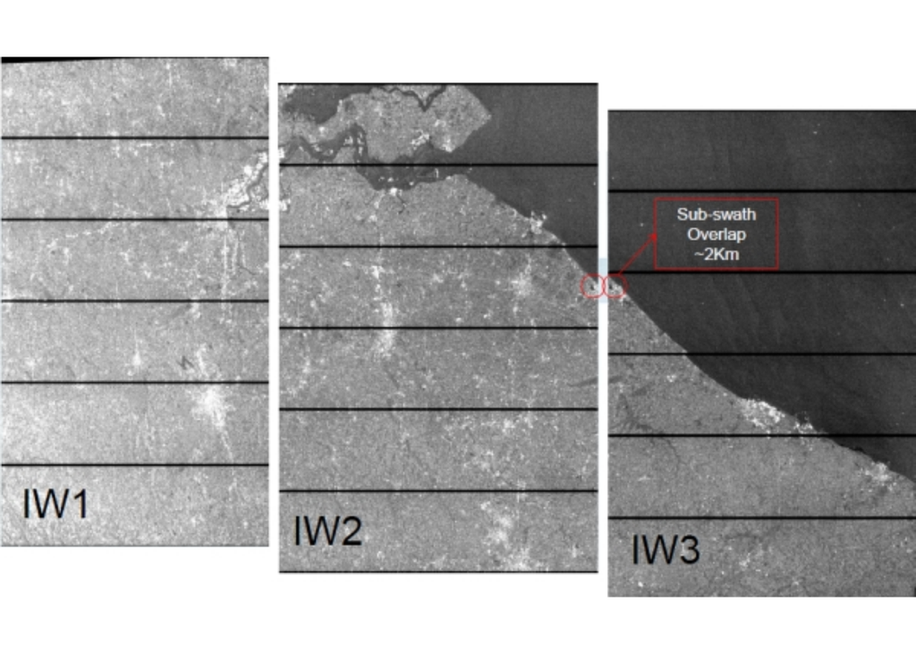

After the TOPSAR-Splitting the exact orbit file is applied increase the coregistration accuracy. and later phase contribution calculation which will be subtracted. Orbit files are automatically downloaded if available, which is about three weeks after sensing date.

```bash
#in terminal
spyder
```

In the python code adapt inpath_dir (directory where your downloaded images as .zip files are stored), outpath (directory where the splitted image with precise orbit information will be stored), roi_dat (.geojson of the ROI) and IWnum (Number of the subswath the ROI is within).

```python
######################
##user configuration##
######################
inpath_dir = '/path/to/directory/containing/IWSLC_products/'
outpath = '/path/to/directory/'
roi_dat = '/path/to/ROI.geojson'
IWnum = 'IW2'#number of IW where  the ROI is within 'IW1', 'IW2' or 'IW3'
polarisation = 'VV'#'HH'
##load modules
print('Loading modules...')
import os
import sys
import snappy
from snappy import ProductIO
from snappy import GPF
from snappy import HashMap
from sentinelsat import read_geojson, geojson_to_wkt
#Get snappy Operators
GPF.getDefaultInstance().getOperatorSpiRegistry().loadOperatorSpis()
print('Loading modules done!')
##Read data
print('Reading, TOPSAR-Split and Apply-Orbit-File...')
#get filenames for each scene
filenames = os.listdir(inpath_dir)
inpath = ''
out_form = '.dim'
roi = geojson_to_wkt(read_geojson(roi_dat))
#put parameters for TOPSAR-Split operator
#https://github.com/senbox-org/s1tbx/blob/master/s1tbx-op-sentinel1/src/main/java/org/esa/s1tbx/sentinel1/gpf/TOPSARSplitOp.java
parameters_split = HashMap()
parameters_split.put('subswath', IWnum)
parameters_split.put('selectedPolarisations', polarisation)
parameters_split.put('wktAoi', roi)
#put parameters for Apply-Orbit-File
parameters_ao = HashMap()
parameters_ao.put('orbitType', "Sentinel Precise (Auto Download)")
parameters_ao.put('polyDegree', 3)
parameters_ao.put('continueOnFail', False)
#prepare object to store split_ao_results for Back-Geocoding operator
prodset = []
for i in range(len(filenames)):
    inpath_r = inpath_dir+filenames[i]
    outpath_r = outpath + filenames[i][0:25] + '_split_oa' + out_form
    img = ProductIO.readProduct(inpath_r)
    ###################
    ####TOPSAR-Split####
    ####################
    print('TOPSAR-Split for ' + filenames[i][0:25])
    img_split = GPF.createProduct('TOPSAR-Split', parameters_split, img)
    print('TOPSAR-Split for ' + filenames[i][0:25] + 'done!')
    #deleting input data
    del img
    ########################
    ####Apply-Orbit-File####
    ########################
    print('Apply-Orbit-File for ' + filenames[i][0:25])
    #execute Apply-Orbit-File operator
    img_split_ao = GPF.createProduct('Apply-Orbit-File', parameters_ao, img_split)
    ProductIO.writeProduct(img_split_ao, outpath_r, 'BEAM-DIMAP')
    del img_split
    print('Apply-Orbit-File for ' + filenames[i][0:25] + 'done!')
    prodset.append(img_split_ao)
    del img_split_ao
print('Reading, TOPSAR-Split and Apply-Orbit-File done!')
```

### 4.1.2 Select master with optimal baseline

The products produced in the last step, have to be stacked. In order to do so, one product has to be the master in this stack. Finding the optimal master is done in python as well.

```python
#find Optimal Master Product
InSARStackOverview = snappy.jpy.get_type('org.esa.s1tbx.insar.gpf.InSARStackOverview')
opt_master = InSARStackOverview.findOptimalMasterProduct(prodset)
#get PRODUCT string for optimal Master Product
opt_master = opt_master.getMetadataRoot().getElement('Abstracted_Metadata').getAttribute('PRODUCT').getData()
ProductData = snappy.jpy.get_type('org.esa.snap.core.datamodel.ProductData')
master = ProductData.getElemString(opt_master)
print master
```

Note the name printed in the console and close spyder.

### 4.1.3 Back-Geocoding to produce stack

To coregistrate the SLC images, the Back-Geocoding operator can be executed using snappy, but python is rather slow doing this step, one other step is to use gpt, hence we have to produce one single stack, the simple GUI solution is used here. Go to your output directory and open all splitted and orbit file applied products (.dim) in SNAP. Go to Radar ⇨ Coregistration ⇨ S1 TOPS Coregistration ⇨ S-1 Back Geocoding. In *ProductSet-Reader* choose *Add Opened* to add all loaded products. Select the product which should become the master and use the ⤒ to make it the first product of the set. You can also sort the images by their date with these arrows, but be sure the first image remains the optimal master image, despite its date. Set the parameters in *Back-Geocoding* and an output path in *Write* and hit *Run*, the process takes some time.

It is possible, that the Back-Geocoding operator returns an [error like](http://forum.step.esa.int/t/error-of-interferogram-in-snap/3424/8) org.jblas.NativeBlas.dgemm(CCIIID[DII[DIID[DII)V). If that is the case, the libgfortran3 package must be installed on your machine. This error occurs mainly on fresh installed Kubuntu OS which have not been used that much or any other packages are installed beside the packages mentioned in the Installation section, hence the package is missing.

```bash
#in terminal
apt-get install libgfortran3
```

The result is a stack, the first three bands are the bands of the master product i, q and Intensity.

### 4.1.4 TOPSAR-Deburst

To get rid of the effects on the edges, the TOPSAR-Deburst operator is used. Hence the stack was created using the GUI I recommend to open spyder again and continue processing in python, because it is again a single step, you can even use the GUI, that is on you.

```bash
#in terminal
spyder
```

Append the parameters inpath_stack (the path to the output of the Back-Geocoding operator) and outpath (path where the output will be stored)

```python
######################
##user configuration##
######################
inpath_stack = '/home/user/PSI/backgeoc/S1A_IW_SLC__1SDV_20170101_Stack.dim'
outpath = '/home/user/PSI/dbrst/'
out_form = '.dim'
##load modules
print('Loading modules...')
import sys
import snappy
from snappy import ProductIO
from snappy import GPF
from snappy import HashMap
#Get snappy Operators
GPF.getDefaultInstance().getOperatorSpiRegistry().loadOperatorSpis()
print('Loading modules done!')
#Read data
print('Reading stack...')
prodset = ProductIO.readProduct(inpath_stack)
print('Reading stack done!')
######################
####TOPSAR-Deburst####
######################
print('TOPSAR-Deburst...')
#put parameters for TOPSAR-Deburst
parameters = HashMap()
parameters.put('selectedPolarisations', 'VV')
#execute TOPSAR-Deburst
prodset_bgc_dbrst = GPF.createProduct('TOPSAR-Deburst', parameters, prodset)
ProductIO.writeProduct(prodset_bgc_dbrst, outpath + "stack_bgc_dbrst" + out_form, 'BEAM-DIMAP')
print('TOPSAR-Deburst done!')
```

### 4.1.5 Subset

A spatial subset will be done, to further minimize the dataset to be processed. Therefore the ROI or another subset polygon you prefer is used again by snappy.

```bash
#in terminal
spyder
```

```python
####################
#User Configuration#
####################
out_form = ".dim"
inpath = '/home/user/psstack/20170101_Stack_deb.dim'
outpath_substack = '/home/user/psstack/20170101_PS_subset' + out_form
subpoly_path = '/home/user/studysiteinfo/subset.geojson'
###################################
#import modules and SNAP operators#
###################################
print('Importing modules and SNAP operators...')
import os
import sys
import snappy
from snappy import ProductIO
from snappy import GPF
from snappy import HashMap
from sentinelsat import read_geojson, geojson_to_wkt
#Get snappy Operators
GPF.getDefaultInstance().getOperatorSpiRegistry().loadOperatorSpis()
WKTReader = snappy.jpy.get_type('com.vividsolutions.jts.io.WKTReader')
print('Importing modules and SNAP operators done!')
####################################
###read in .geojson conver to WKT###
####################################
print('reading geojson and convert to WKT...')
wkt = geojson_to_wkt(read_geojson(subpoly_path))
geom = WKTReader().read(wkt)
print('reading geojson and convert to WKT done!')
#######################################
###band and spatial subset of stacks###
#######################################
print('Subsetting stacks...')
stack = ProductIO.readProduct(inpath)
band_names = list(stack.getBandNames())
parameters = HashMap()
parameters.put('geoRegion', geom)
#parameters.put('sourceBands', band_names)
parameters.put('copyMetadata', True)

sub_stack = GPF.createProduct("Subset", parameters, stack)
del stack
ProductIO.writeProduct(sub_stack, outpath_substack, 'BEAM-DIMAP')
del sub_stack
print('Subsetting stack done!')
```

### 4.1.6 Interferogram formation

Now it is time to process interferograms with the stacked and subseted data. Since SNAP 6.0 is available some steps have changed from the original workflow introduces by [katherine](http://forum.step.esa.int/t/workflow-between-snap-and-stamps/3211/152?u=thho). With the current version, it is possible to add needed data as lat, lon and elevation bands in one step and even terrain correction afterwards is not needed any more to avoid a shifting effect, which were seen in previous versions, [tested and reported by FeiLiu here](http://forum.step.esa.int/t/how-to-prepare-sentinel-1-images-stack-for-psi-sbas-in-snap-5/4981/390?u=thho).

Select your subset and go to Radar ⇨ Interferometric ⇨ Products ⇨ Interferogram Formation. Name the product to be written *stack_deb_sub_ifg.dim*. In Processing Parameters… enable *Subtract flat earth phase, Subtract topographic phase, Output Elevation and Output Orthorectified Lat/Lon*. Hit *Run*.

### 4.1.7 StaMPS Export

Finally…we can export to StaMPS and the stopover will be reached soon!  
Create a target folder named INSAR_master_date like INSAR_20170310 where the date yyyymmdd denotes the maste date.

```bash
#in terminal
mkdir /home/thho/PSI/INSAR_20170310/
```

In SNAP, go to Radar ⇨ Interferometric ⇨ PSI/SBAS ⇨ Export StaMPS. As input select the two products *stack_deb_sub.dim* and *stack_deb_sub_ifg.dim*, whereby the debursted stack must be on top. The target folder is the folder which was created just before INSAR_master_date. Hit *Run*.

The folder INSAR_master_date has to look like this:

```bash
ls /home/thho/PSI/INSAR_20170310/
```

[output not shown]

## 4.2 StaMPS PS analysis

### 4.2.1 Preparation

As mentioned in Configuration, the StaMPS_CONFIG.bash must be called in each terminal which is opened to work with StaMPS. That means, the terminal which is opened must not be closed. For instance, Matlab, which will call scripts from the StaMPS installation, must be called from this terminal only and not via the application launcher or something similar.

The steps described below are just a brief workflow of StaMPS, I really recommend to read the [StaMPS handbook](https://homepages.see.leeds.ac.uk/~earahoo/stamps/StaMPS_Manual_v3.3b1.pdf) where the steps and parameters are described in detail!

```bash
#adapt stamps version
#open terminal (further StaMPS-terminal) and close it when you finished all steps in StaMPS
source /home/user/StaMPS_v4.x/StaMPS_CONFIG.bash

#<yyyymmdd> must be the date of the master
mt_prep_snap <yyyymmdd> /home/user/PSI/INSAR_master_date/ 0.4
```

During processing, check if there are no warnings for Zero mean values! If there are warnings for a specific date, this image is corrupt and the whole preprocessing has to be done again, therefore it is crucial to check the results after the step Split-Orbit File apply, because there the errors mostly occur.

### 4.2.2 Test Matlab

Before we use the first Matlab script, we should check if Matlab works properly.

```bash
#in StaMPS-terminal
matlab
```

Matlab opens and we can try:

```matlab
getparm
```

A list of parameters should be returned, if not, check section Configuration and your PATH variable.

Now it is more or less technically ‘easy’ to analyse PS with StaMPS.

```matlab
stamps(1,8)
```

But to know what is happening, it is a good idea to start with executing each step by step. The first number of the two parameters is the beginning step the second the last step. To just run the first step, do:

```matlab
stamps(1,1)
```

### 4.2.4 Plotting with StaMPS

After Step five, you have the option to plot the wrapped phase, to check them visually. The command in matlab is:

```matlab
ps_plot('w')
```

This produced an error in my case, because of a break command in the Matlab script parseplotprm.m. This may occur in some other plot commands too, it did in my case. But it is easy to fix this. The error will tell you in which line the break command occurs, just go to the matlab folder of your StaMPS installation, open the affected script and command (%) the whole line and save the script. In Matlab, call the same plot again and it should work.

After all, you should be able to process your data.

# Bibliography

Berardino, P., Fornaro, G., Lanari, R., Sansosti, E., 2002. A new algorithm for surface deformation monitoring based on small baseline differential SAR interferograms. IEEE Transactions on Geoscience and Remote Sensing 40, 2375–2383. https://doi.org/10.1109/TGRS.2002.803792

De Zan, F., Monti-Guarnieri, A.M., 2006. TOPSAR: Terrain observation by progressive scans. IEEE Transactions on Geoscience and Remote Sensing 44, 2352–2360. https://doi.org/10.1109/TGRS.2006.873853

ESA, 2018. User guides. Sentinel-1 SAR. Acquisition modes. Interferometric Wide swath [WWW Document]. URL {https://sentinel.esa.int/web/sentinel/user-guides/sentinel-1-sar/acquisition-modes/interferometric-wide-swath} (accessed 30.01.2017).

Ferretti, A., Monti-Guarnieri, A., Prati, C., Rocca, F., Massonnet, D., 2007. InSAR principles. Guidelines for SAR interferometry processing and interpretation. ESA Publications TM-19, Noordwijk.

Ferretti, A., Prati, C., Rocca, F., 2001. Permanent scatterers in SAR interferometry. IEEE Transactions on Geoscience and Remote Sensing 39, 8–20. https://doi.org/10.1109/36.898661

Ferretti, A., Prati, C., Rocca, F., 2000. Nonlinear subsidence rate estimation using permanent scatterers in differential SAR interferometry. IEEE Transactions on Geoscience and Remote Sensing 38, 2202–2212. https://doi.org/10.1109/36.868878

Franceschetti, G., Lanari, R., 1999. Synthetic aperture radar processing. CRC Press, Boca Raton.

Hooper, A., 2010. A statistical-cost approach to unwrapping the phase of InSAR time series. European Space Agency, (Special Publication) SP-677, 1–5.

Hooper, A., 2008. A multi‐temporal InSAR method incorporating both persistent scatterer and small baseline approaches. Geophysical Research Letters 35, 1–5. https://doi.org/10.1029/2008GL034654

Hooper, A., 2006. Persistent scatterer radar interferometry for crustal deformation studies and modeling of volcanic deformation (PhD thesis). Stanford University.

Hooper, A., Bekaert, D., Spaans, K., 2013. StaMPS/MTI Manual. Version 3.3b1. School of Earth and Environment, University of Leeds, Leeds.

Hooper, A., Bekaert, D., Spaans, K., Arıkan, M., 2012. Recent advances in SAR interferometry time series analysis for measuring crustal deformation. Tectonophysics 514-517, 1–13. https://doi.org/10.1016/j.tecto.2011.10.013

Hooper, A., Segall, P., Zebker, H., 2007. Persistent scatterer interferometric synthetic aperture radar for crustal deformation analysis, with application to Volcán Alcedo, Galápagos. Journal of Geophysical Research: Solid Earth 112, 1–21. https://doi.org/10.1029/2006JB004763

Hooper, A., Zebker, H., Segall, P., Kampes, B., 2004. A new method for measuring deformation on volcanoes and other natural terrains using InSAR persistent scatterers. Geophysical Research Letters 31, 1–5. https://doi.org/10.1029/2004GL021737

Lauknes, T., 2004. Long-term surface deformation mapping using small-baseline differential sar interferograms (Master’s thesis). University of Tromso, Norway, Tromso.

Rosen, P., Hensley, S., Joughin, I., Li, F., Madsen, S., Rodriguez, E., Goldstein, R., 2000. Synthetic aperture radar interferometry. Proceedings of the IEEE 88, 333–382. https://doi.org/10.1109/5.838084

Simons, M., Rosen, P., 2007. 3.12 - interferometric synthetic aperture radar geodesy, in: Schubert, G. (Ed.), Treatise on Geophysics. Elsevier, Amsterdam, pp. 391–446. https://doi.org/https://doi.org/10.1016/B978-044452748-6.00059-6